Saba Syed Phys191-03 Shaon Ghosh 09/25/2020 Lab 3

# Motion in two dimensions - Concepts of vectors

## The Objective:

#### The objective of this lab is to study motion in two dimensions and find out how velocity vector can be broken into components to study the motion. To illustrate this we will be using the motion of a projectile.

## The Introduction:

In this experiment we will launch a projectile (a metallic ball) by using an inclined plane of the side of a table. The experimental setup is shown below. Due to the inclination angle the ball will accelerate down the plane. Once it reaches the edge of the table it will drop off freely under the force of gravity.

However, the ball will not fall vertically down as we observed in the case of the dropping of the metallic ball in the first experiment. Instead it will follow a parabollic trajectory as shown in the diagram below. This is due to the fact that the ball actually has a velocity at the time it is leaving the surface (unlike in the first experiment where it was merely dropped from a 2m height). This velocity $(v_f)$ is along the plane. Since velocity is a vector quantity, It can be decomposed into two components, a horizontal component ,$v_f\cos\theta$, and a vertical component, $v_f\sin\theta$, as shown in the figure. The horizontal component of the velocity will continue to take the ball away from the table while the ball is falling under gravity. That is the reason it does not fall vertically down.

We will see how the component of the velocity will result in change in the result of how far the ball will be launched away from the table.

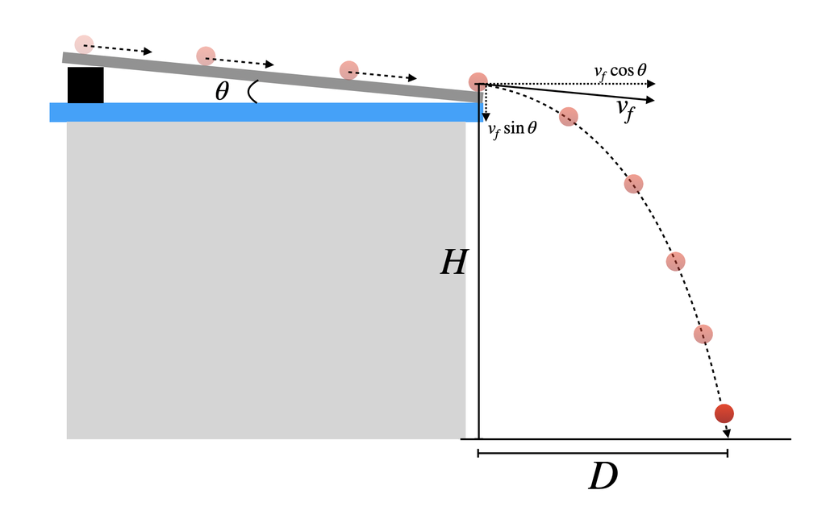

```python
from IPython.display import Image
Image('fig1.png', width=1000, height=1000)
```

## Materials:

1. A flat surface that can be inclined to different angles (could be just a table or plank from previous experiment)
2. A device to measure angles of the surface (could be the inclinometer in your Physics Toolbox app)
3. Small hard ball (similar to one used for the first experiment)
4. Stopwatch
5. Wooden blocks to change inclination angles (could be thick books)
6. A long scale/measuring tape to measure height.

## Theory:

### Horizontally launched projectiles:

When a projectile is launched from a height horizontally, its component of velocity in the vertical direction is zero, and the entire velocity is in the horizontal direction at the initial point. Earth's gravity will give the projectile a velocity in the vertical direction, however that will have no effect on its velocity in the horizontal direction. Thus, the projectile will continue to have the same horizontal velocity its entire time of flight, and that will determine how fast it will be moving in the horizontal direction. However, the vertical motion will determine how long this motion will last, since once the projectile hits the ground, the motion will cease. Thus, the duration of the flight is given by the time the projectile takes to hit the ground. This is given by $t = \sqrt{\frac{2H}{g}}$, where $H$ is the height from there the projectile is launched. Therefore we the distance the projectile will travel from the point it is launched is given by $D = v_ft = v_f\sqrt{\frac{2H}{g}}$.

### Projectile launched from an incline plane:

However, our case is slightly more complicated. The projectile is launched from an inclined plane, and therefore not horizontally. As a result of that the time of flight needs to be modified using the kinematic equation, $H = v_fT\sin\theta + \frac{1}{2}gT^2$. One can calculate the value of the time of the flight, $T$, by solving the above quadratic equation, giving us,

### $T = \sqrt{\frac{v_f^2\sin^2\theta}{g^2} + \frac{2H}{g}} - \frac{v_f\sin\theta}{g}$.

Hence the corrected range of the projectile (taking into account the angle of inclination) is:

### $D = v_f\left[\sqrt{\frac{v_f^2\sin^2\theta}{g^2} + \frac{2H}{g}} - \frac{v_f\sin\theta}{g}\right]\cos\theta$.

## Procedure:

#### Set up your system like your did in the case of the velocity-acceleration experiment.

### 1. Measure the angle of inclination.

You will be doing this experiment five times, with five different values of the inclination angle. Each set will start with measurement of the inclination angle. If you are using the phone app, the simplest way measure the angle will be to put the phone on the surface for about a minute and note the smallest and the larget value of the angle shown on your inclinometer during that interval. Take the mean of these two values, and use that as your angle of inclination.

### 2. Measure the velocity of the projectile.

We will use a technique similar to the velocity-acceleration experiment. Place the ball at the farthest possible end of the inclined plan (in the raised side). In the instruments provided in the lab, this will provide a 120 cm of rolling-length for the ball. Let the ball go (with no horizintal velocity) and start the stopwatch immediately. Stop the watch the moment it has reached the end of the slide. Repeate this ten times. If you realize during the experiment, that you have done something incorrectly in one of the readings (too early, or too late on the stopwatch for example), scratch that data.

### 3. Projectile motion.

Measure the height of the point from where the projectile will be launched. Make sure to mark the ground vertically beneath this point. Let the projectile go, and see how far from the table the projectile travels before hitting the ground. Measure this distance from the point your marked vertically under the launching point. Repeat this experiment 10 times and take the average to find the range. Remember to always launch the projectile carefully by letting it roll from the same position and from a state of rest.

Calculate the expected distance from the two above equation, $D_{\rm approx} = v_f\sqrt{\frac{2H}{g}}$, and $D_{\rm corrected} = v_f\left[\sqrt{\frac{v_f^2\sin^2\theta}{g^2} + \frac{2H}{g}} - \frac{v_f\sin\theta}{g}\right]\cos\theta$ by plugging in the values of $v_f$, $\theta$, $H$, and use $g=9.8~{\rm ms^{-2}}$.

Repeat this experiment four more times, gradually increasing the inclination angle.

### 4. Plotting:

Plot the measured value of $D$ from the experiment in the $x$-axis, and the inferred values from the range $D_{\rm approx}$ and $D_{\rm corrected}$ in the $y$-axis. What relationship between the two values do you observe. Discuss this explain your observation.

## Analysis:

```python
import numpy as np
import pandas as pd
import pylab as pl

### In this cell put the number of the constants and initial conditions ###


g = 9.8  # Acceleration due to gavity
L = 1.2 # Rolling length of the plank. I did the lab at home this is 1.2 meter.

# First angle measured using Physics Toolbox was about 2.36 degrees #
theta_1 = np.deg2rad(2.36)

# Second angle measured using Physics Toolbox was about 3.98 degrees #
theta_2 = np.deg2rad(3.98)

# Third angle measured using Physics Toolbox was about 7.94 degrees #
theta_3 = np.deg2rad(7.94)



# Fourth angle measured using Physics Toolbox was about 8.93 degrees #
theta_4 = np.deg2rad(8.93)

# Fifth angle measured using Physics Toolbox was about 10.68 degrees #
theta_5 = np.deg2rad(10.68)
```

### Create a functions that will compute the relevant quantities and spit out the answer

```python
def compute_final_velocity(roll_times, length=L):
    '''
    This function takes as input the slide times and spits out the value of the
    final velocity.

    Arguments:
    roll_times :: This should be a numpy array
    length :: The length of the slide. By default it will pick up the length you provided above.

    Example function call:
    x = np.array([2.87, 2.9, 2.93, 2.91, 2.88, 2.87, 2.94, 2.9, 2.91, 2.84])
    compute_final_velocity(x)
    >> 0.8290155440414507
    '''
    average_slide_time = np.mean(roll_times)
    v_avg = length/average_slide_time
    vf = 2*v_avg

    return vf



def compute_range(height, angle, final_velocity, g=g):
    '''
    This function takes as input the height of the launching point above ground (H), and
    spits out the value of value of the range.

    Arguments:
    height :: The height (H) in meters of the point of launching above the ground.
    angle :: Angle of the incline in degrees that was used to roll the ball
    final_velocity :: Final velocity computed from the previous function call
    g :: Acceleration due to gravity. Default value will be pick from cell above
    '''

    time_of_fall = (2*height/g)**0.5
    angle = np.deg2rad(angle) # Convert the angle to radians
    R = final_velocity*time_of_fall

    R_corr = (1/g)*((final_velocity*np.sin(angle))**2 + 2*g*H)**0.5 - final_velocity*np.sin(angle)/g
    R_corr = R_corr*final_velocity*np.cos(angle)

    return [R, R_corr]
```

```python
# First set #
roll_times_1 = np.array([2.46, 2.48, 2.34, 2.35, 2.36, 2.28, 2.36, 2.24, 2.11, 2.04])
vf1 = compute_final_velocity(roll_times_1)

# Measured height and distance of using Meter-scale
H = 0.928
D_measured1 = 0.44
[D_approx1, D_corrected1] = compute_range(H, theta_1, vf1)
```

```python
# Second set #
roll_times_2 = np.array([2.49, 2.39, 2.20, 2.39, 2.33, 2.03, 2.17, 2.29, 2.38, 2.33])
vf2 = compute_final_velocity(roll_times_2)

# Measured height and distance of using Meter-scale
H = 0.928
D_measured2 = 0.46
[D_approx2, D_corrected2] = compute_range(H, theta_2, vf2)
```

```python
# Third set #
roll_times_3 = np.array([2.46, 2.24, 2.36, 1.97, 1.98, 2.07, 2.11, 1.98, 1.96, 1.96])
vf3 = compute_final_velocity(roll_times_3)

# Measured height and distance of using Meter-scale
H = 0.928
D_measured3 = 0.50
[D_approx3, D_corrected3] = compute_range(H, theta_3, vf3)
```

```python
## Fourth set (change the angle)
roll_times_4 = np.array([2.06, 2.18, 1.94, 2.17, 1.83, 2.05, 1.65, 1.70, 2.06, 2.18])
vf4 = compute_final_velocity(roll_times_4)

## Copy lines from the previous cell and change the names of the variable accordingly
# Measured height and distance of using Meter-scale
H = 0.928
D_measured4 = 0.53
[D_approx4, D_corrected4] = compute_range(H, theta_4, vf4)
```

```python
## Fifth set (change the angle)
roll_times_5 = np.array([1.99, 1.83, 1.86, 1.69, 1.58, 1.63, 1.56, 1.47, 1.37, 1.44])
vf5 = compute_final_velocity(roll_times_5)

## Copy lines from the previous cell and change the names of the variable accordingly
# Measured height and distance of using Meter-scale
H = 0.928
D_measured5 = 0.62
[D_approx5, D_corrected5] = compute_range(H, theta_5, vf5)
```

|  | Trial # | Measured range | Approx inferred range | Corrected Range for inclination |
| --- | --- | --- | --- | --- |
| 0 | 1.0 | 0.44 | 0.453714 | 0.453634 |
| 1 | 2.0 | 0.46 | 0.454108 | 0.453973 |
| 2 | 3.0 | 0.50 | 0.495234 | 0.494913 |
| 3 | 4.0 | 0.53 | 0.526967 | 0.526558 |
| 4 | 5.0 | 0.62 | 0.636083 | 0.635371 |

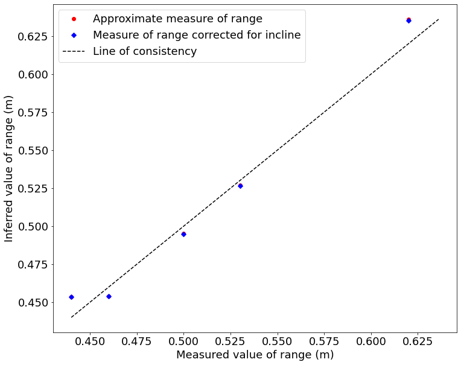

```python
### Collect data and make plots ###

trials = np.array([1, 2, 3, 4 , 5], dtype=int)
D_measured = np.array([D_measured1, D_measured2, D_measured3, D_measured4, D_measured5])
D_approx = np.array([D_approx1, D_approx2, D_approx3, D_approx4, D_approx5])
D_corrected = np.array([D_corrected1, D_corrected2, D_corrected3, D_corrected4, D_corrected5])

df = pd.DataFrame(np.vstack((trials, D_measured, D_approx, D_corrected)).T,
                 columns=["Trial #", "Measured range", "Approx inferred range",
                          "Corrected Range for inclination"])


pl.rcParams.update({'font.size': 18})
pl.figure(figsize=(12,10))
pl.plot(D_measured, D_approx, 'ro', label="Approximate measure of range")
pl.plot(D_measured, D_corrected, 'bD', label="Measure of range corrected for incline")
pl.xlabel("Measured value of range (m)")
pl.ylabel("Inferred value of range (m)")
Min = np.min([D_measured, D_approx])
Max = np.max([D_measured, D_approx])
pl.plot([Min, Max], [Min, Max], 'k--', label="Line of consistency")
pl.legend()
df
```

## Fractional error

Frctional error is calculated by taking the difference of the experimental value from the true value and then dividing it by the true value. In this experiment the true value is not known, so we are going to calculate the fractional error w.r.t between the measured value and the calculated value. We are going to pretend that the measured value `D_measured` is the true value, and hence the resulting fractional error is:

### $\Delta R = \frac{D_{\rm calculated} - D_{\rm measured}}{D_{\rm measured}}$.

We are going to calculate this quantity for both the approximate result and the corrected result.The expectation is that the difference between the two should be small, but the fraction error should be lower for the corrected case. The reason we expect the results to be very close is because the value of the angle very small in general. Thus the ball is being lanunched almost horizontal. The approximate result assumes that the ball is launched horizontally, which is not very wrong under the small-angle assumption.

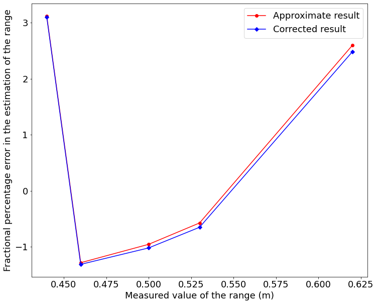

```python
### first calcualate the fractional errors ###
Delta_approx = (D_approx - D_measured)/D_measured
Delta_corrected = (D_corrected - D_measured)/D_measured

### Now plot them with the measured values ###
pl.rcParams.update({'font.size': 18})
pl.figure(figsize=(12,10))
pl.plot(D_measured, Delta_approx*100, 'ro-', label="Approximate result")
pl.plot(D_measured, Delta_corrected*100, 'bD-', label="Corrected result")
pl.xlabel('Measured value of the range (m)')
pl.ylabel('Fractional percentage error in the estimation of the range')
pl.legend()
```

## Uncertainty Analysis

We will compute the fractional uncertainty in our experiment using error propagation technique. Let us apply that for the simpler case of the $D_{\rm approx}$. The expression we need to use is $D = v_f\sqrt{\frac{2H}{g}}$. We take natural logarithm on both sides to get, $\ln D = \ln v_f + \frac{1}{2}\ln \frac{2H}{g} = \ln v_f + \frac{1}{2}(\ln 2 + \ln H - \ln g)$. How of course, since $2$, and $g$ are constants, we can take a derivtive on both sides, to get $\frac{dD}{D} = \frac{dv_f}{v_f} + \frac{1}{2}\frac{dH}{H}$. From this we can write the fractional uncertainty in the measurement of the distance $D_{\rm approx}$ is

### $\frac{\Delta D_{\rm approx}}{D_{\rm approx}} = \left|\frac{\Delta v_f}{v_f}\right| + \frac{1}{2}\left|\frac{\Delta H}{H}\right|$,

where, $\Delta H$ is the least count of the meter scale that we used to measure the distance to the spot on the ground where the projectile hit from the point vertically beneath the launching point. This is is typically $= 1~{\rm mm}$. To find $\left|\frac{\Delta v_f}{v_f}\right|$, we note that $v_f = 2v_{\rm avg} = \frac{2L}{t}$, where $L$ is the full length the projectile rolled on the inclined plane, and $t$ is the time it took to roll. Using the same argument above, $\left|\frac{\Delta v_f}{v_f}\right| = \left|\frac{\Delta t}{t}\right|$. Thus, the fractional error in the measurement of the approximate distance $D_{\rm approx}$ is,

### $\frac{\Delta D_{\rm approx}}{D_{\rm approx}} = \left|\frac{\Delta t}{t}\right| + \frac{1}{2}\left|\frac{\Delta H}{H}\right|$,

where $\Delta t$ is the least count in the stopwatch, which in the case of the lab-supplied stopwatch is $10~{\rm ms}$.

We can of course do the same analysis for the corrected result, but the expression will be too complicated, and is unnecessary, since that will just add the error in our angle measurement on top of this, which is not the main source of error.

```python
## Plotting with uncertainty ##
delta_t = 0.01  # least count in stopwatch = 0.01 s
delta_H = 0.001  # least count in ruler = 1 mm
t_uncertainty = np.array([delta_t/np.mean(roll_times_1), delta_t/np.mean(roll_times_2), delta_t/np.mean(roll_times_3), delta_t/np.mean(roll_times_4), delta_t/np.mean(roll_times_5)])
H_uncertainty = np.array([delta_H/0.928, delta_H/0.928, delta_H/0.928, delta_H/0.928, delta_H/0.928])
uncertainty = t_uncertainty + 0.5*H_uncertainty
print(uncertainty)
```

```
[0.00488284 0.00488662 0.00528038 0.0055842  0.00662893]
```

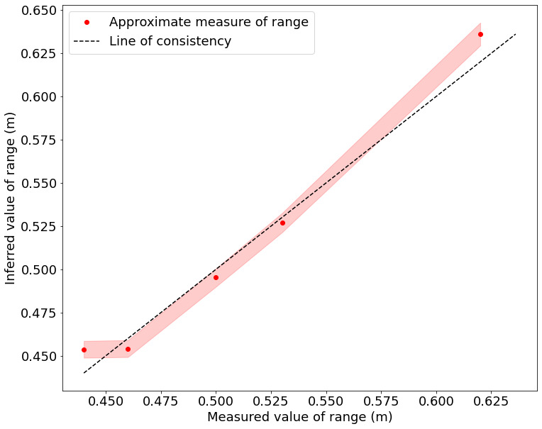

```python
pl.rcParams.update({'font.size': 18})
pl.figure(figsize=(12,10))

pl.fill_between(D_measured, D_approx + uncertainty, D_approx - uncertainty, alpha=0.2, color='r')
pl.plot(D_measured, D_approx, 'ro', label="Approximate measure of range")
pl.xlabel("Measured value of range (m)")
pl.ylabel("Inferred value of range (m)")
Min = np.min([D_measured, D_approx])
Max = np.max([D_measured, D_approx])
pl.plot([Min, Max], [Min, Max], 'k--', label="Line of consistency")
pl.legend()
```

## Discussions and Conclusions:

This lab to understand the concept of vectors when experiment by rolling a ball off an incline plank and using my phone to calculation the velocity-acceleration of the fall. This lab became easier because I am used to of JupyterHub. First that was done was measuring the angle of inclination which was very important to demostrate on the graph so there is not any confusion. This part was easy with having the app but I had to be careful on how I used it to aviod any future errors.Then, I measured the velocity of the projectile which was tricky to do with the app and the person that was helping me getting it wrong a couple times so retries had to be made. The projection motion was the height of my inclination where the ball was being launched and slowly was increasing the incline. Of course, I found the range of the tries for each of my set to show the accuracy. All the experiments were repeated 10 times for accuracy of the information that will be put into tables then to go on graphs. The Fractral graph is showing the error of my lab. I have to say that my lab does not have a very big difference in the error portion but it is slighty off. The Uncertainty Analysis shows the line of consistency and my points from my range. My points are very close to the line of consistency.